# Data Story on US presidents’ inaugural speeches

## sentiment analysis

Explore the emotion difference between speeches from each president with the NRC emotion lexicon. The get_nrc_sentiment function returns a data frame in which each row represents a sentence from the original file. The columns include one for each emotion type.

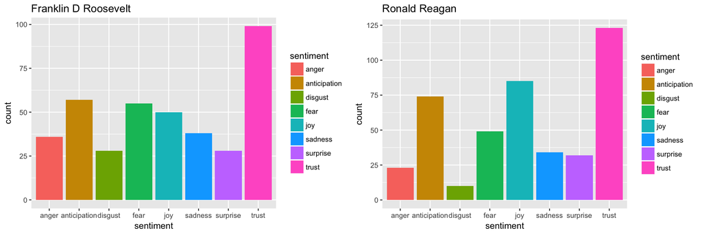

```r
#FranklinDRoosevelt
d.1<-get_nrc_sentiment(Roosevelt)
td.1<-data.frame(t(d.1))
td_new.1 <- data.frame(rowSums(td.1[-1]))
#Transformation and  cleaning
names(td_new.1)[1] <- "count"
td_new.1 <- cbind("sentiment" = rownames(td_new.1), td_new.1)
rownames(td_new.1) <- NULL
td_new2.1<-td_new.1[1:8,]
#Visualisation
plot.1<-qplot(sentiment, data=td_new2.1, weight=count, geom="bar",fill=sentiment)+ggtitle("Franklin D Roosevelt")
#RonaldReagan
d.2<-get_nrc_sentiment(Reagan)
td.2<-data.frame(t(d.2))
td_new.2 <- data.frame(rowSums(td.2[-1]))
#Transformation and  cleaning
names(td_new.2)[1] <- "count"
td_new.2 <- cbind("sentiment" = rownames(td_new.2), td_new.2)
rownames(td_new.2) <- NULL
td_new2.2<-td_new.2[1:8,]
#Visualisation
plot.2<-qplot(sentiment, data=td_new2.2, weight=count, geom="bar",fill=sentiment)+ggtitle("Ronald Reagan")
grid.arrange(plot.1, plot.2,ncol=2)
```

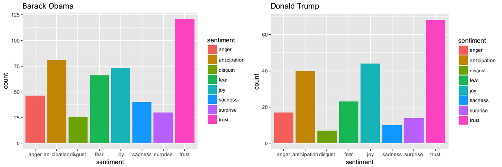

```r
#BarackObama
d.3<-get_nrc_sentiment(obama)
td.3<-data.frame(t(d.3))
td_new.3 <- data.frame(rowSums(td.3[-1]))
#Transformation and  cleaning
names(td_new.3)[1] <- "count"
td_new.3 <- cbind("sentiment" = rownames(td_new.3), td_new.3)
rownames(td_new.3) <- NULL
td_new2.3<-td_new.3[1:8,]
#Visualisation
plot.3<-qplot(sentiment, data=td_new2.3, weight=count, geom="bar",fill=sentiment)+ggtitle("Barack Obama")
#Donald Trump
d.4<-get_nrc_sentiment(Trump)
td.4<-data.frame(t(d.4))
td_new.4 <- data.frame(rowSums(td.4[-1]))
#Transformation and  cleaning
names(td_new.4)[1] <- "count"
td_new.4 <- cbind("sentiment" = rownames(td_new.4), td_new.4)
rownames(td_new.4) <- NULL
td_new2.4<-td_new.4[1:8,]
#Visualisation
plot.4<-qplot(sentiment, data=td_new2.4, weight=count, geom="bar",fill=sentiment)+ggtitle("Donald Trump")
grid.arrange(plot.3, plot.4,ncol=2)
```

NRC emotion lexicon divides emotion into eight types: anger, fear, anticipation, trust, surprise, sadness, joy, and disgust. In the plot, each bar represents how prominent each of the emotion is in text. One thing worth noticing is that although inaugurated under major economic crises, Reagan’s emotion is very different from those of the other two presidents. He shows more positive attitude in his speech. While Roosevelt and Obama have relatively balanced speech and share similar emotion distribution. Trump is the one who has the least negative emotion in his speech. His chart is a combination of high trust and joy with a low sadness and disgust. That reflects the situation Trump is at the moment of the speech.